# R Programming

## You will learn about…

> 1. vectors ✓  
> 2. matrices  
> 3. data frames  
> 4. lists

## What's the difference?

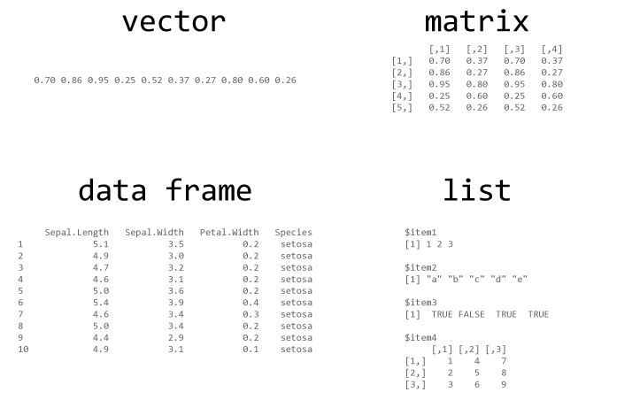

## Matrices

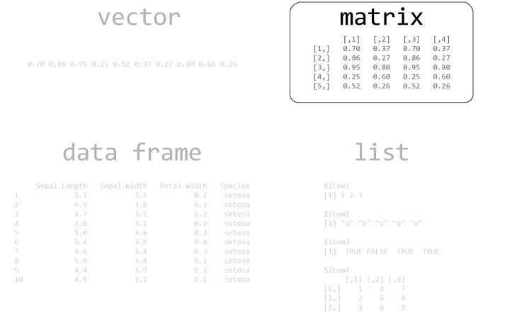

## Your Turn - #1

> 1. read in the gallons.matrix.rds file  
> 2. what are the dimension of this matrix?  
> 3. what are the row and column names for this matrix  
> 4. index for all years for aircraft 18 & 48  
> 5. index for aircraft 2, 10 & 53 for years 2010-2012

## Your Turn - #2

> 1. read in the gallons.matrix.rds file  
> 2. remove aircraft with missing observations  
> 3. compute the overall average gallons burned  
> 4. compute annual total gallons burned  
> 5. compute aircraft average burn rate  
> Bonus: which aircraft has the highest burn rate?

## Data frames

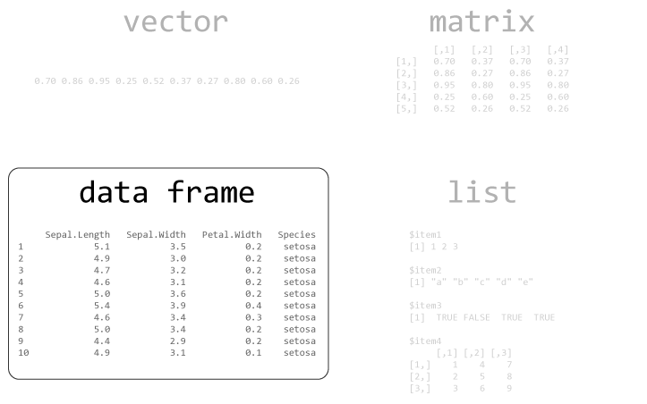

## Your Turn - #3

> 1. read in the aircraft.rds file  
> 2. what are the dimensions of this data frame?  
> 3. provide a summary of this data frame  
> 4. select the MD, FH, and Cost columns  
> 5. select observations 1-50

## Your Turn - #4

> 1. read in the aircraft.rds file  
> 2. are there any NAs in this data frame?  
> 3. what is the median operating cost across all data?  
> 4. subset for observations that exceed the median cost  
> 5. subset for bombers that exceed the median cost and return MD, year, & FHs

## Lists

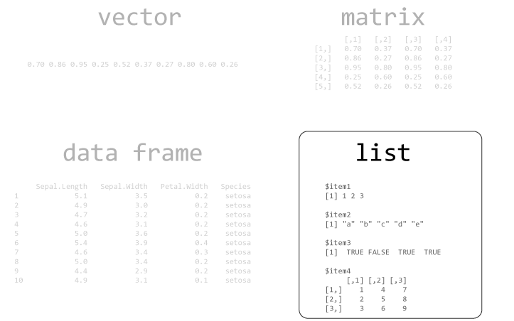

## Your Turn - #5

> 1. read in the aircraft.rds file  
> 2. type this in console: `ac_model <- lm(Cost ~ Type + MD + FH, data = aircraft)`  
> 3. what are the names of the items in the ac_model list?  
> 4. extract the residuals from this list and summarize them?  
> Bonus: are these residuals approximately normally distributed?

## Learn More

> https://afit-r.github.io

> » Data Structures Section